# tarea_ex

Abraham Nieto 51556

4 de noviembre de 2018

```r
library(R2OpenBUGS)
library(R2jags)
wdir<-"/home/abraham/RA2018/tareas/tar_bill"
setwd(wdir)

#--- Funciones utiles ---
prob<-function(x){
  out<-min(length(x[x>0])/length(x),length(x[x<0])/length(x))
  out
}
```

```r
#Leemos datos
bill<-read.table("BillsMXc.csv",sep=",",header=TRUE)
head(bill)
```

```
##   Year    C  Y x20 x50 x100 x200 x500
## 1 2000 2182 15   1   0    0    0    0
## 2 2001 2093 13   1   0    0    0    0
## 3 2002 2182 18   1   0    0    0    0
## 4 2003 2449  9   1   0    0    0    0
## 5 2004 2546  2   1   0    0    0    0
## 6 2005 2708  1   1   0    0    0    0
```

```r
x<-bill$C#/1000
y<-bill$Y#/1000
```

Realizamos el mismo eercicio que el examen con las betas optimas con la liga logistica y tenemos:

```r
n<-nrow(bill)
#-Defining data-
#data<-list(x1=sal$X1,x2=sal$X2,x3=sal$X3)
data<-list("n"=n,"y"=y,"e"=bill$C,"x20"=bill$x20,"x50"=bill$x50,"x100"=bill$x100,"x200"=bill$x200,"x500"=bill$x500)
#-Defining inits-
inits<-function(){list(beta=rep(0,6),yf=rep(0,n))}
parameters<-c("beta","yf")

#OpenBUGS
ex1<-bugs(data,inits,parameters,model.file="eja.txt",
               n.iter=100000,n.chains=2,n.burnin=10000)
```

```r
res<-function(func,out){
  ex1.sim<-func
  #out<-ex1.sim$sims.list


 for(i in 1:6){
  b<-out$beta[,i]
  par(mfrow=c(1,1))
  plot(b,type="l",xlab = "beta")
  plot(cumsum(b)/(1:length(b)),type="l",xlab = "beta")
  hist(b,freq=FALSE, main = "beta")
  acf(b)
 }
  plot(out$beta)

  #out.sum<-ex1.sim$summary
  #return(ex1.sim)

}

rex<-function(fun){return(fun)}
```

Tenemos las nuevas betas y el DIC da 1297 con liga logistica…

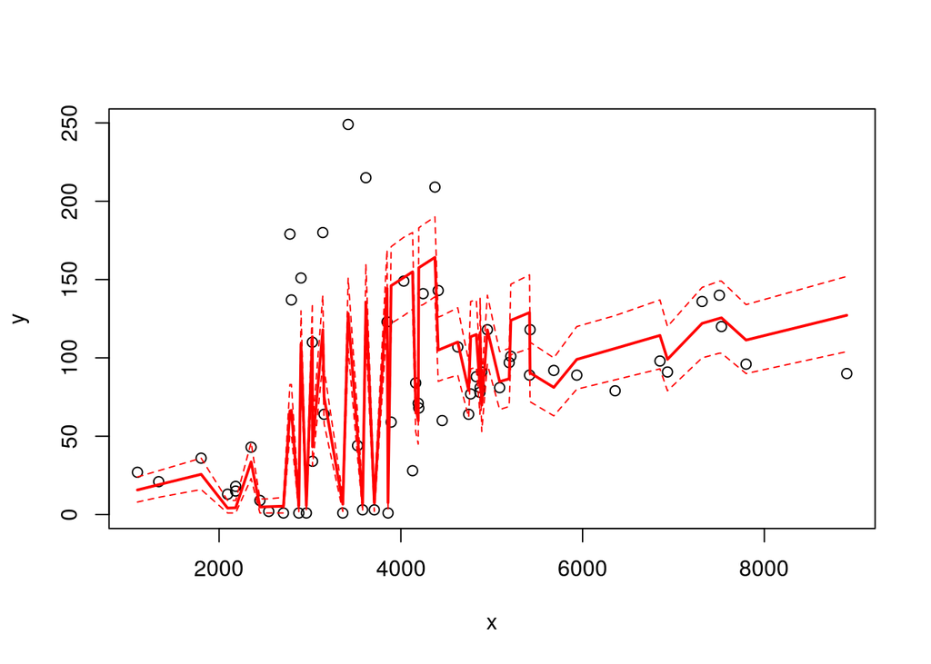

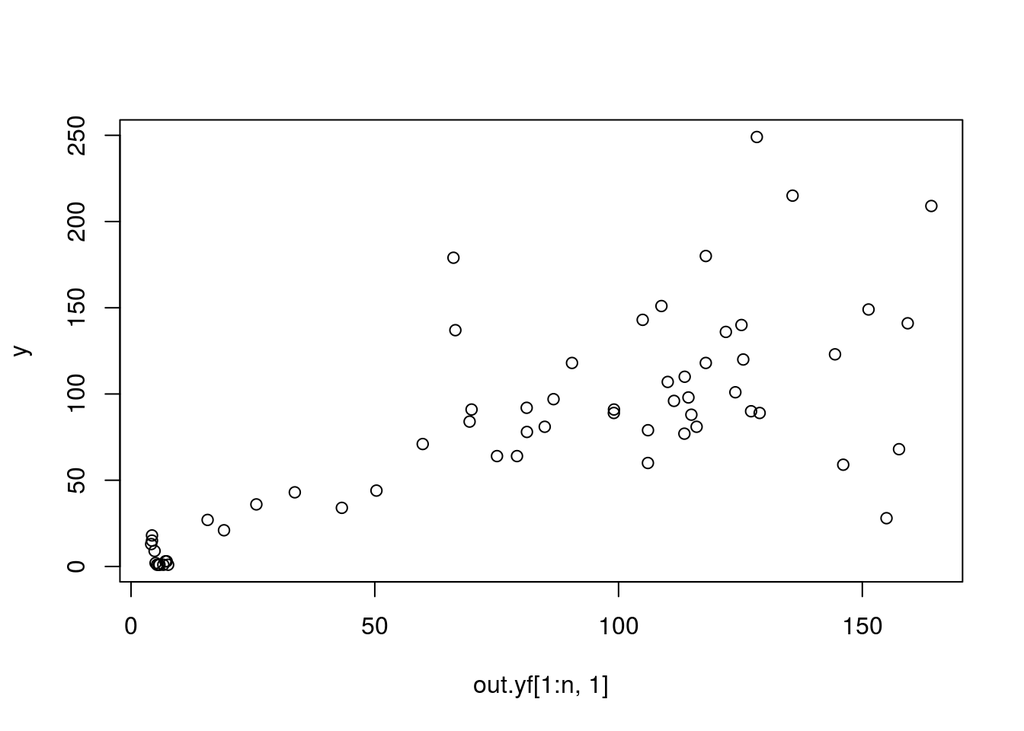

```r
out<-rex(ex1)$sims.list

out.sum<-rex(ex1)$summary

#Predictions
adj<-function(out.sum,y,a){
  out.yf<-out.sum[grep(a,rownames(out.sum)),]
  or<-order(x)
  ymin<-min(y,out.yf[,c(1,3,7)])
  ymax<-max(y,out.yf[,c(1,3,7)])
  par(mfrow=c(1,1))
  plot(x,y,ylim=c(ymin,ymax))
  lines(x[or],out.yf[or,1],lwd=2,col=2)
  lines(x[or],out.yf[or,3],lty=2,col=2)
  lines(x[or],out.yf[or,7],lty=2,col=2)

  plot(out.yf[1:n,1],y,type ="p")

}

adj(out.sum,y,"yf")
```

```r
#DIC
met<-function(ex1.sim,out.sum){
  out.dic<-ex1.sim$DIC
  #out.dic<-ej4.sim$BUGSoutput$DIC
  print(out.dic)
  print(out.sum)
}

#out.sum[grep("beta",rownames(out.sum)),c(1,3,7)]
met(ex1,out.sum[grep("beta",rownames(out.sum)),c(1,3,7)] )
```

```
## [1] 1297
##               mean        2.5%   97.5%
## beta[1] -4.3010603 -4.35600000 -4.2490
## beta[2] -1.9329972 -2.13100000 -1.7460
## beta[3]  1.0563827  0.99170000  1.1220
## beta[4]  0.5867010  0.51820000  0.6562
## beta[5]  0.2240540  0.15490000  0.2939
## beta[6]  0.0658603 -0.01134025  0.1443
```

```r
r2<-function(y,out.sum,a){
  out.yf<-out.sum[grep(a,rownames(out.sum)),]
  R2<-(cor(y,out.yf[1:n,1]))^2
  print(R2)
}

r2(y,out.sum,"yf")
```

```
## [1] 0.5544818
```

Aqui todos los coeficientes excepto el de 500 son significativos el DIC 1297 y r2=.554

y Ahora con Clog-log:

```r
parameters<-c("beta","yf")
#OpenBUGS
ex2<-bugs(data,inits,parameters,model.file="eje.txt",
          n.iter=100000,n.chains=2,n.burnin=10000)
#traceplot(ex2)
```

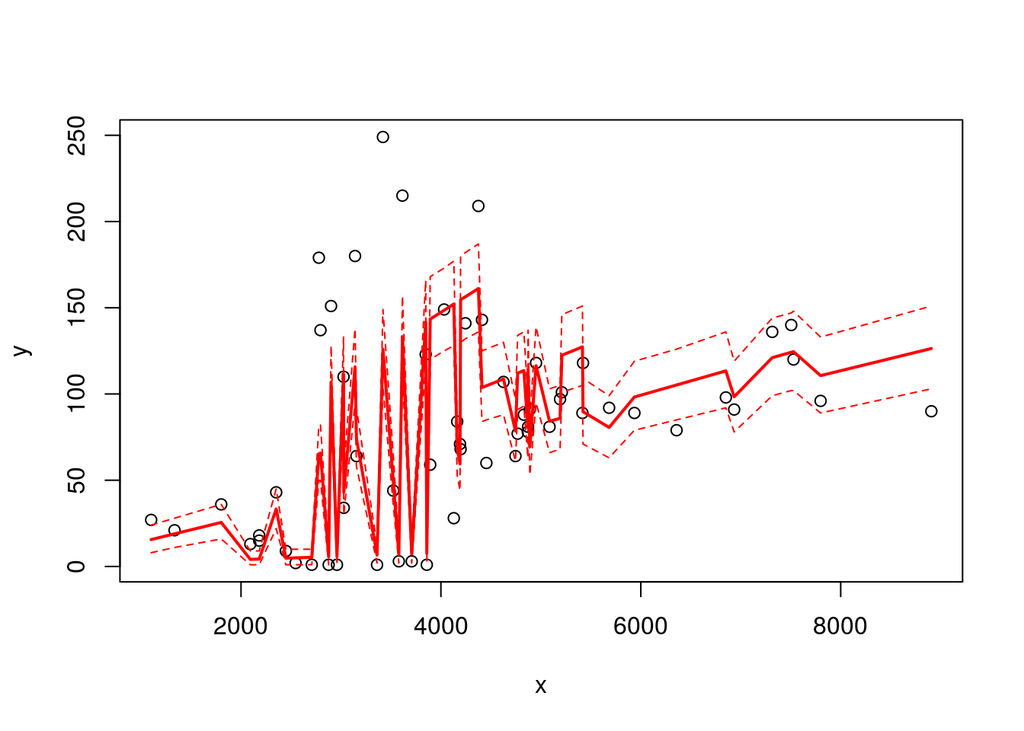

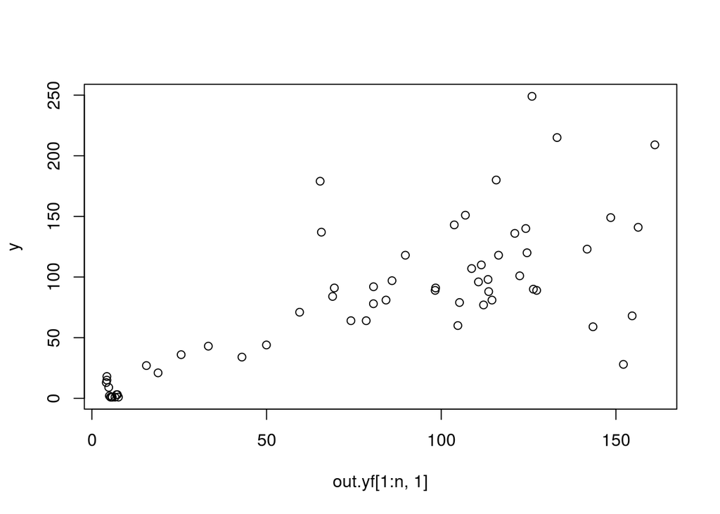

```r
out2<-rex(ex2)$sims.list

out2.sum<-rex(ex2)$summary


#res(ex2,out2)
#ajustes
adj(out2.sum,y,"yf")
```

```r
#estimaciones y DIC
met(ex2,out2.sum[grep("beta",rownames(out2.sum)),c(1,3,7)])
```

```
## [1] 1297
##                mean      2.5%   97.5%
## beta[1] -4.31075864 -4.365000 -4.2590
## beta[2] -1.92522422 -2.125000 -1.7400
## beta[3]  1.04683429  0.983600  1.1130
## beta[4]  0.58391143  0.517600  0.6541
## beta[5]  0.22548783  0.155700  0.2950
## beta[6]  0.06898769 -0.008041  0.1467
```

```r
#R2
r2(y,out2.sum,"yf")
```

```
## [1] 0.553878
```

con funcion cloglog obtnemos el dic de 1297 y una r2 de .553

por tanto escogemos como el mejor modelo al de la liga logistica ya que su r2 es mayor.

ejea.txt ***************************************************************************************

model{ #Likelihood

for (i in 1:n){

y[i]~dbin(pi[i],e[i])

logit(pi[i])<-b[1]+b[2]*x20[i]+b[3]*x50[i]+b[4]*x100[i]+b[5]*x200[i]+b[6]*x500[i]

}

# Priors

for (j in 1:6){

b[j]~dnorm(0,0.001)

}

# estimate betas

beta[1]<-b[1]+mean(b[2:6]) for(j in 2:6){beta[j]<-b[j]-mean(b[2:6])}

for (i in 1:n) { yf[i] ~ dbin(pf[i],e[i]) logit(pf[i])<-beta[1]+beta[2]*x20[i]+beta[3]*x50[i]+beta[4]*x100[i]+beta[5]*x200[i]+beta[6]*x500[i]}

}

eje.txt ******************************************************************************** model{ #Likelihood

for (i in 1:n){

y[i]~dbin(pi[i],e[i])

cloglog(pi[i])<-b[1]+b[2]*x20[i]+b[3]*x50[i]+b[4]*x100[i]+b[5]*x200[i]+b[6]*x500[i]

}

# Priors

for (j in 1:6){

b[j]~dnorm(0,0.001)

}

# estimate betas

beta[1]<-b[1]+mean(b[2:6]) for(j in 2:6){beta[j]<-b[j]-mean(b[2:6])}

for (i in 1:n) { yf[i] ~ dbin(pf[i],e[i]) logit(pf[i])<-beta[1]+beta[2]*x20[i]+beta[3]*x50[i]+beta[4]*x100[i]+beta[5]*x200[i]+beta[6]*x500[i]}

} *********************************************************************************************